# Food Deserts and Health Outcomes: A Census Tract-Level Analysis

**Group Members:** Jiaoer Ma, Jian Shi | **Section:** Tue/Thu 11:00am | **GitHub:** JiaoerM

## Research Question

To what extent do food deserts correlate with chronic disease rates at the U.S. census tract level, and does this relationship hold after controlling for income, race, and geography? If food desert status independently predicts worse health outcomes beyond what poverty alone explains, that strengthens the case for targeted food access interventions over purely income-support programs.

## Data & Approach

We merged two datasets on the 11-digit census tract FIPS code, yielding **56,327 tracts across 48 states**. The **USDA Food Access Research Atlas (2019)** classifies tracts as food deserts if they are both low-income and low-access (>1 mile from a supermarket in urban areas, >10 miles in rural). The **CDC PLACES (2022)** dataset provides model-based prevalence estimates for diabetes, obesity, high blood pressure, and smoking at the tract level. After cleaning, we computed group comparisons, Pearson correlations, OLS regressions with controls, and income-stratified breakdowns. We then built a five-tab Streamlit dashboard for interactive exploration.

The main technical difficulty was the FIPS merge: USDA stored tract IDs as floats (e.g., `1001020100.0`) while CDC stored them as strings, causing a near-empty join until both were cast to zero-padded 11-character strings. On deployment, Streamlit Cloud required converting all local file paths to relative paths and fixing a Plotly choropleth bug where full state names needed mapping to 2-letter abbreviations.

## Static Plots

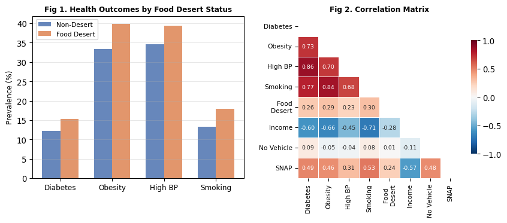

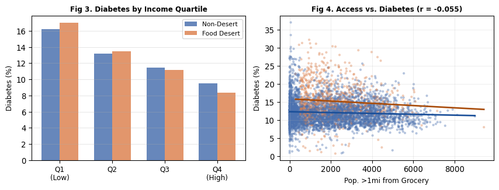

## Streamlit App

The dashboard has five tabs filtered by a global sidebar (health outcome, state, urban/rural, income range). The **Correlation Explorer** plots any food access measure against any health outcome with live Pearson r and regression lines by food desert group. The **State Map** shows a choropleth switchable between food desert prevalence and each health outcome. **Group Comparison** displays bar charts, violin plots, and the income-quartile breakdown. **Regression** runs a live OLS model with a coefficient table and 95% CI plot. **Tract Explorer** provides a searchable table with a live correlation heatmap. Together the tabs allow users to interrogate the food desert-health relationship geographically, statistically, and with flexible confounder controls.

## Limitations

This analysis is cross-sectional and cannot establish causality. There is a temporal mismatch between the USDA (2019) and CDC (2022) data. All results are at the tract level and subject to the ecological fallacy. The binary food desert definition obscures continuous variation in access, and unmeasured confounders (healthcare access, built environment) likely explain part of the observed associations.